# R統計與繪圖

簡立宇、Chatgpt

2023-03-19

> 統計程式碼參考:https://tinaj0508.github.io/R_TextMing/R%E7%B5%B1%E8%A8%88%E8%AA%9E%E6%B3%95%E6%95%B4%E7%90%86.html 製圖參考:https://bookdown.org/jefflinmd38/r4biost/dataviz.html#%E7%B9%AA%E5%9C%96%E5%A5%97%E4%BB%B6-ggplot2

# 一、統計:以Correlation Isn’t Causation為例

```r
##整理資料
data <- data.frame(Year = c(1999:2009),
                   Nicholas_Cage = c('2','2','2','3','1','1','2','3','4','1','4'), #電影出現尼可拉斯凱吉的次數
                   Drowned = c(109,102,102,98,85,95,96,98,123,94,102)) #在游泳池溺水的人數

View(data)
attach(data)

str(Nicholas_Cage)
```

```
##  chr [1:11] "2" "2" "2" "3" "1" "1" "2" "3" "4" "1" "4"
```

```r
Nicholas_Cage <- as.integer(Nicholas_Cage)
str(Nicholas_Cage)
```

```
##  int [1:11] 2 2 2 3 1 1 2 3 4 1 ...
```

```r
##觀察資料
summary(Nicholas_Cage)
```

```
##    Min. 1st Qu.  Median    Mean 3rd Qu.    Max.
##   1.000   1.500   2.000   2.273   3.000   4.000
```

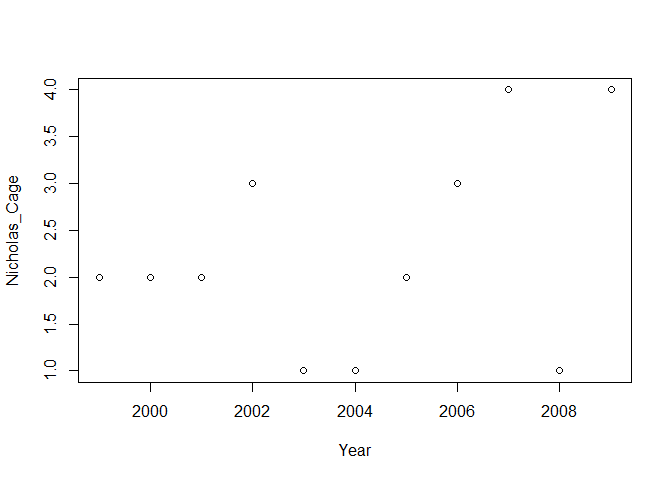

```r
plot(Year,Nicholas_Cage)
```

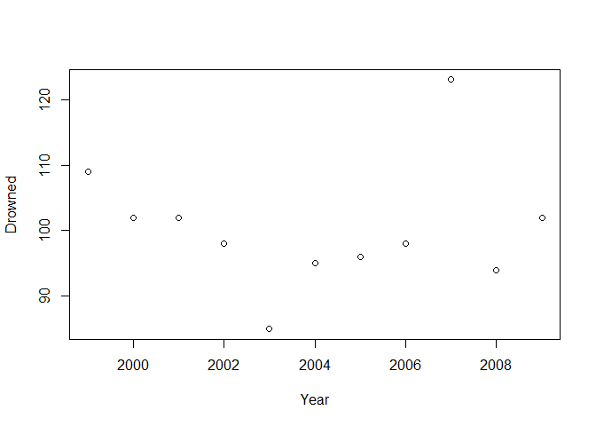

```r
plot(Year,Drowned)
```

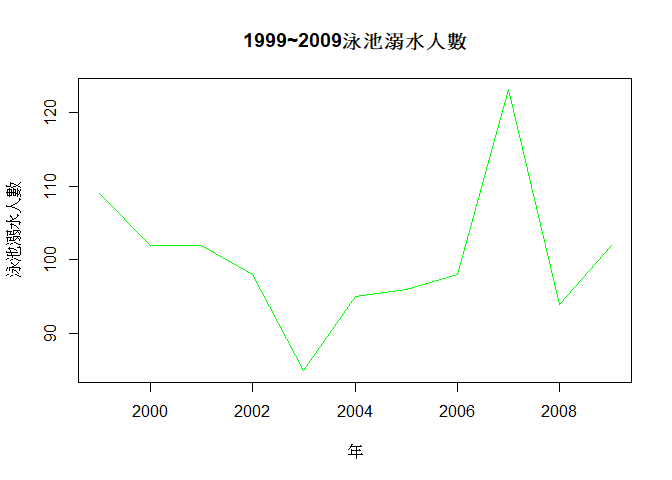

```r
plot(Year,Drowned, type="l", col="green", lwd=1, xlab="年", ylab="泳池溺水人數", main="1999~2009泳池溺水人數")
```

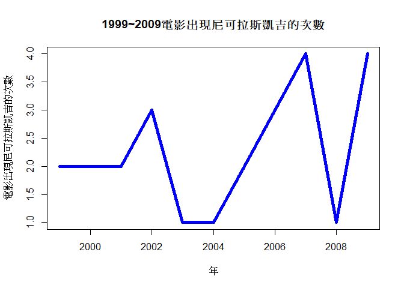

```r
plot(Year,Nicholas_Cage, type="l", col="blue", lwd=5, xlab="年", ylab="電影出現尼可拉斯凱吉的次數", main="1999~2009電影出現尼可拉斯凱吉的次數")
```

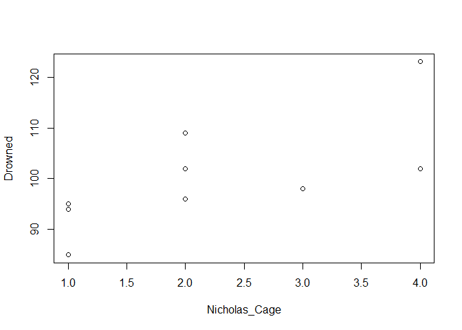

```r
plot(Nicholas_Cage, Drowned)
```

```r
##相關性分析
cov(Nicholas_Cage, Drowned)
```

```
## [1] 7.090909
```

> gpt小僕人:在 R 中，cov() 函数用于计算两个向量之间的协方差。协方差是描述两个变量之间线性关系的一种度量，其结果可以告诉我们这两个变量是如何随着彼此变化的。cov() 函数的语法为：cov(x, y)。其中 x 和 y 是两个向量，可以是数值型向量、因子型向量等。如果 x 和 y 是数值型向量，则协方差计算公式为： cov(x, y) = sum((x - mean(x)) * (y - mean(y))) / (n - 1) 其中 mean(x) 和 mean(y) 分别为 x 和 y 向量的均值，n 是向量的长度。协方差可以取任意的值，其大小和符号可以反映出两个变量之间的关系。具体而言：当协方差为正值时，说明两个变量呈正相关，即当一个变量增加时，另一个变量也增加。当协方差为负值时，说明两个变量呈负相关，即当一个变量增加时，另一个变量减少。当协方差为零时，说明两个变量之间不存在线性关系。需要注意的是，协方差只能反映出两个变量之间的线性关系，不能说明因果关系。当两个变量之间存在因果关系时，需要进一步的研究和分析。

```r
cor(Nicholas_Cage, Drowned)
```

```
## [1] 0.6660043
```

```r
##迴歸分析
mod1 <- lm(Nicholas_Cage ~ Drowned , data = data)
summary(mod1)
```

```
##
## Call:
## lm(formula = Nicholas_Cage ~ Drowned, data = data)
##
## Residuals:
##     Min      1Q  Median      3Q     Max
## -0.9308 -0.5926 -0.1020  0.4836  1.6026
##
## Coefficients:
##             Estimate Std. Error t value Pr(>|t|)
## (Intercept) -5.37515    2.86726  -1.875   0.0936 .
## Drowned      0.07620    0.02845   2.678   0.0253 *
## ---
## Signif. codes:  0 '***' 0.001 '**' 0.01 '*' 0.05 '.' 0.1 ' ' 1
##
## Residual standard error: 0.8678 on 9 degrees of freedom
## Multiple R-squared:  0.4436, Adjusted R-squared:  0.3817
## F-statistic: 7.174 on 1 and 9 DF,  p-value: 0.02527
```

```r
coef(mod1)
```

```
## (Intercept)     Drowned
## -5.37514654  0.07620164
```

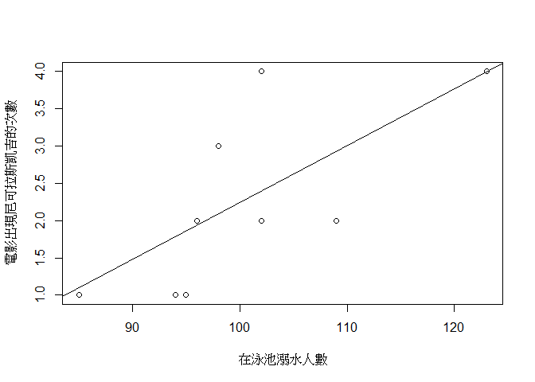

```r
plot(Drowned, Nicholas_Cage,
     xlab = "在泳池溺水人數",
     ylab = "電影出現尼可拉斯凱吉的次數",
     type = "p")
abline(mod1)
```

```r
detach(data)
```

## 練習1

這裡有一個美國學生資料集，請檢視缺席數(absences)與性別(sex)、談戀愛(romantic)、工作日喝酒(Dalc)之間的關係，並做簡單的描述統計。

> 變數解釋: sex - student’s sex (binary: ‘F’ - female or ‘M’ - male) romantic - with a romantic relationship (binary: yes or no) Dalc - workday alcohol consumption (numeric: from 1 - very low to 5 - very high) absences - number of school absences (numeric: from 0 to 93) 資料來源:https://www.kaggle.com/datasets/uciml/student-alcohol-consumption?select=student-mat.csv

```r
url = "https://raw.githubusercontent.com/guipsamora/pandas_exercises/master/04_Apply/Students_Alcohol_Consumption/student-mat.csv"
tmp<-rio::import(url)
View(tmp)
```

## 練習1參考答案

```r
library(ggplot2)
attach(tmp)
table(sex)
```

```
## sex
##   F   M
## 208 187
```

```r
table(Dalc)
```

```
## Dalc
##   1   2   3   4   5
## 276  75  26   9   9
```

```r
table(romantic)
```

```
## romantic
##  no yes
## 263 132
```

```r
table(absences)
```

```
## absences
##   0   1   2   3   4   5   6   7   8   9  10  11  12  13  14  15  16  17  18  19
## 115   3  65   8  53   5  31   7  22   3  17   3  12   3  12   3   7   1   5   1
##  20  21  22  23  24  25  26  28  30  38  40  54  56  75
##   4   1   3   1   1   1   1   1   1   1   1   1   1   1
```

```r
#plot(absences)

##重新編碼sex
nsex <- sex
nsex[sex == "M"] <- 1
nsex[sex == "F"] <- 0
table(nsex)
```

```
## nsex
##   0   1
## 208 187
```

```r
str(nsex)
```

```
##  chr [1:395] "0" "0" "0" "0" "0" "1" "1" "0" "1" "1" "0" "0" "1" "1" "1" ...
```

```r
nsex <- as.integer(nsex)

##重新編碼romantic
nromantic <- romantic
nromantic[romantic == "no"] <- 0
nromantic[romantic == "yes"] <- 1
table(nromantic)
```

```
## nromantic
##   0   1
## 263 132
```

```r
str(nromantic)
```

```
##  chr [1:395] "0" "0" "0" "1" "0" "0" "0" "0" "0" "0" "0" "0" "0" "0" "1" ...
```

```r
nromantic <- as.integer(nromantic)

#plot(sex,absences)
#plot(nsex,absences)

cov(nromantic,absences)
```

```
## [1] 0.5797725
```

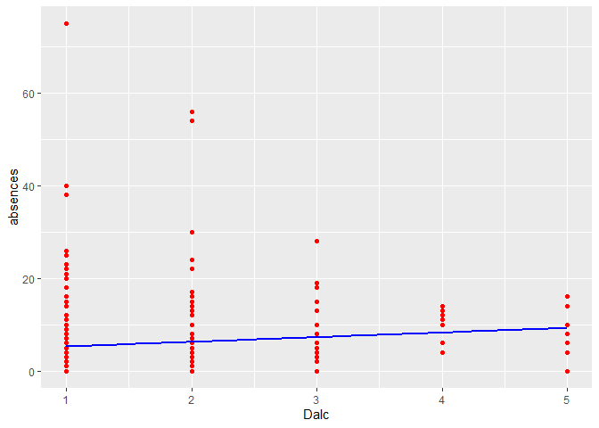

```r
#plot(Dalc,absences)
ggplot(tmp, aes(x= Dalc,y = absences)) +
    geom_point(col='red') +
    geom_smooth(method="lm", se=F, col='blue')
```

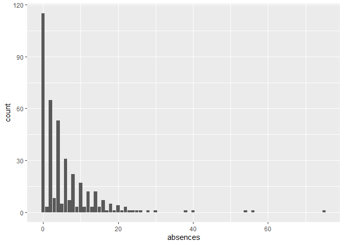

```r
##因為變數多事是binary變數，所以用上面的方法畫圖不好看
library(ggplot2)

ggplot(tmp,
       aes(x = absences,
           fill = nsex)) + #nsex發現畫不出來，要轉換成factor
  geom_bar(position = "dodge")
```

```r
#factor轉換
comment(nsex) <- "sex group" #定義變數及數值
nsex2 <- factor(nsex, levels = c(0,1),
                   labels = c("F", "M"))
table(nsex2)
```

```
## nsex2
##   F   M
## 208 187
```

```r
str(nsex2)
```

```
##  Factor w/ 2 levels "F","M": 1 1 1 1 1 2 2 1 2 2 ...
```

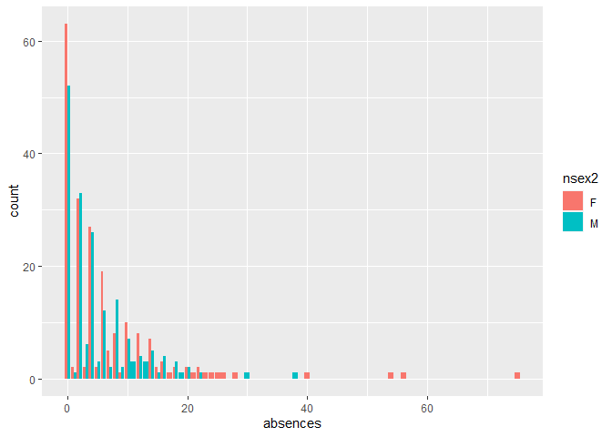

```r
#再畫一次
ggplot(tmp,
       aes(x = absences,
           fill = nsex2)) +
  geom_bar(position = "dodge")
```

```r
##如果用廻歸分析....要用哪種廻歸呢?
##看依變數與自變數是哪種變數!!!!
##若以absences為依變數，其他條件為自變數
##(1)把absences當連續變數就得用lm (簡單或多廻歸)
mod3 <- lm(absences ~ nsex + Dalc + nromantic, data = tmp)
summary(mod3)
```

```
##
## Call:
## lm(formula = absences ~ nsex + Dalc + nromantic, data = tmp)
##
## Residuals:
##    Min     1Q Median     3Q    Max
## -8.606 -4.781 -1.582  2.020 67.593
##
## Coefficients:
##             Estimate Std. Error t value Pr(>|t|)
## (Intercept)   3.7960     0.8481   4.476 9.99e-06 ***
## nsex         -1.4122     0.8273  -1.707  0.08861 .
## Dalc          1.1987     0.4619   2.595  0.00982 **
## nromantic     2.4124     0.8437   2.859  0.00447 **
## ---
## Signif. codes:  0 '***' 0.001 '**' 0.01 '*' 0.05 '.' 0.1 ' ' 1
##
## Residual standard error: 7.86 on 391 degrees of freedom
## Multiple R-squared:  0.04267,    Adjusted R-squared:  0.03533
## F-statistic:  5.81 on 3 and 391 DF,  p-value: 0.0006825
```

```r
coef(mod3)
```

```
## (Intercept)        nsex        Dalc   nromantic
##    3.795992   -1.412182    1.198673    2.412405
```

```r
mod5 <- lm(absences ~ Dalc, data = tmp)
summary(mod5)
```

```
##
## Call:
## lm(formula = absences ~ Dalc, data = tmp)
##
## Residuals:
##    Min     1Q Median     3Q    Max
## -9.247 -5.225 -2.242  1.775 69.775
##
## Coefficients:
##             Estimate Std. Error t value Pr(>|t|)
## (Intercept)   4.2198     0.7781   5.423 1.02e-07 ***
## Dalc          1.0055     0.4504   2.233   0.0261 *
## ---
## Signif. codes:  0 '***' 0.001 '**' 0.01 '*' 0.05 '.' 0.1 ' ' 1
##
## Residual standard error: 7.963 on 393 degrees of freedom
## Multiple R-squared:  0.01252,    Adjusted R-squared:  0.01001
## F-statistic: 4.984 on 1 and 393 DF,  p-value: 0.02614
```

```r
coef(mod5)
```

```
## (Intercept)        Dalc
##    4.219752    1.005466
```

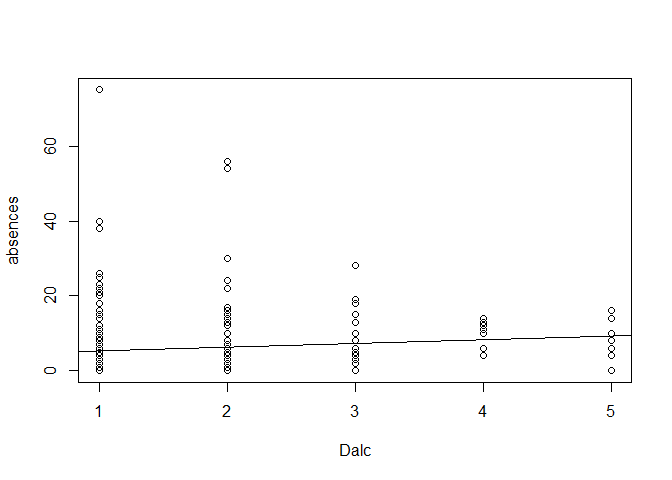

```r
plot( Dalc,absences,
     xlab = "Dalc",
     ylab = "absences",
     type = "p")
abline(mod5)
```

```r
library(stargazer)
stargazer(mod3, type = "text")
```

```
##
## ===============================================
##                         Dependent variable:
##                     ---------------------------
##                              absences
## -----------------------------------------------
## nsex                          -1.412*
##                               (0.827)
##
## Dalc                         1.199***
##                               (0.462)
##
## nromantic                    2.412***
##                               (0.844)
##
## Constant                     3.796***
##                               (0.848)
##
## -----------------------------------------------
## Observations                    395
## R2                             0.043
## Adjusted R2                    0.035
## Residual Std. Error      7.860 (df = 391)
## F Statistic           5.810*** (df = 3; 391)
## ===============================================
## Note:               *p<0.1; **p<0.05; ***p<0.01
```

```r
#(2)absences是Count Dependent Variable，用glm
rwm.mod1 <- glm(absences ~ nsex + Dalc + nromantic, data = tmp, family = "poisson"(link = "log"))
summary(rwm.mod1)
```

```
##
## Call:
## glm(formula = absences ~ nsex + Dalc + nromantic, family = poisson(link = "log"),
##     data = tmp)
##
## Deviance Residuals:
##     Min       1Q   Median       3Q      Max
## -4.2089  -2.7798  -1.0457   0.9277  14.5775
##
## Coefficients:
##             Estimate Std. Error z value Pr(>|z|)
## (Intercept)  1.42318    0.04374  32.535  < 2e-16 ***
## nsex        -0.25357    0.04516  -5.615 1.96e-08 ***
## Dalc         0.18201    0.02126   8.561  < 2e-16 ***
## nromantic    0.39405    0.04280   9.208  < 2e-16 ***
## ---
## Signif. codes:  0 '***' 0.001 '**' 0.01 '*' 0.05 '.' 0.1 ' ' 1
##
## (Dispersion parameter for poisson family taken to be 1)
##
##     Null deviance: 3223.3  on 394  degrees of freedom
## Residual deviance: 3045.0  on 391  degrees of freedom
## AIC: 4062.4
##
## Number of Fisher Scoring iterations: 6
```

```r
rwm.mod2 <- glm(absences ~  Dalc, data = tmp, family = "poisson"(link = "log"))
summary(rwm.mod2)
```

```
##
## Call:
## glm(formula = absences ~ Dalc, family = poisson(link = "log"),
##     data = tmp)
##
## Deviance Residuals:
##     Min       1Q   Median       3Q      Max
## -4.3898  -3.2417  -1.0705   0.7277  16.1020
##
## Coefficients:
##             Estimate Std. Error z value Pr(>|z|)
## (Intercept)  1.50745    0.03928  38.381  < 2e-16 ***
## Dalc         0.15160    0.02046   7.409 1.27e-13 ***
## ---
## Signif. codes:  0 '***' 0.001 '**' 0.01 '*' 0.05 '.' 0.1 ' ' 1
##
## (Dispersion parameter for poisson family taken to be 1)
##
##     Null deviance: 3223.3  on 394  degrees of freedom
## Residual deviance: 3173.3  on 393  degrees of freedom
## AIC: 4186.7
##
## Number of Fisher Scoring iterations: 6
```

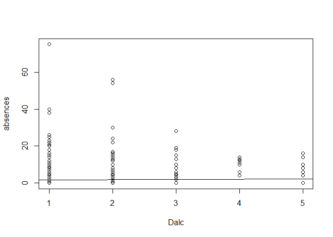

```r
plot( Dalc,absences,
     xlab = "Dalc",
     ylab = "absences",
     type = "p")
abline(rwm.mod2)
```

```r
#流程:做完描述統計、假設檢定(?)之類的後，分析變數之間相關性與是否顯著的分析後，廻歸的診斷等等(但其實很多量化期刊根本沒做)，檢驗廻歸的效力。如果都沒有問題就可以進行模型解讀。(大概最基本的統計分析就j樣子ㄅ)
```

# 二、base plot & ggplot

> gpt小僕人:R 的 base plot 和 ggplot 是兩個常用的繪圖系統，兩者在設計哲學、使用方式、功能特點等方面有著不同的特點。Base plot 是 R 的內置圖形庫，提供了一系列的繪圖函數，例如 plot()、hist()、boxplot()、barplot() 等。Base plot繪製圖形的方式比較直接，通常需要逐步調整設置來達到所需的效果。使用 base plot 可以快速繪製出基本的散點圖、直方圖、箱形圖等等。此外，base plot 的優勢在於其簡單易用和靈活性，它提供了許多的參數可以用來調整圖形的細節，例如線條的顏色、寬度、字體大小等等。ggplot 是另一種常用的 R 繪圖系統，是由 Hadley Wickham 開發的，基於 Grammar of Graphics 設計哲學而來，相較於 base plot 更加靈活、可擴展。ggplot可以幫助用戶更加方便地設計、繪製複雜的圖形，並且具有良好的可重複性。ggplot的主要優勢在於其強大的層疊式設計，用戶可以將不同的圖層放在一起，進行比較、顯示不同變數的關係等等。此外，ggplot 還提供了大量的統計繪圖模板和主題設計，可以讓用戶輕鬆地設計出漂亮的圖形。總的來說，base plot 是一個內置的、易於使用的繪圖庫，適合用於快速繪製基本的圖形。ggplot 則是一個更加靈活、可擴展的繪圖庫，適合用於複雜的數據分析和可視化。根據不同的需求，用戶可以選擇使用不同的繪圖系統來進行數據分析和可視化。

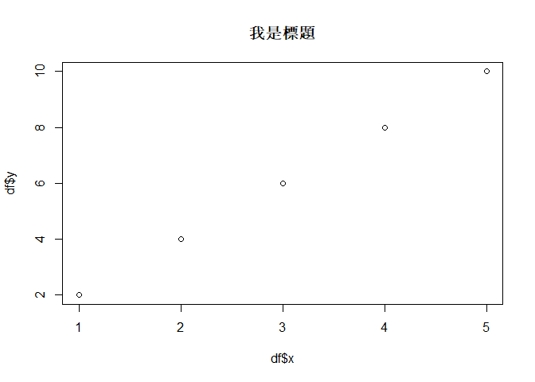

```r
# Load the ggplot2 package
library(ggplot2)

# Create a data frame
df <- data.frame(
  x = c(1, 2, 3, 4, 5),
  y = c(2, 4, 6, 8, 10)
)

# Create the plot
plot(df$x,df$y, main="我是標題")
```

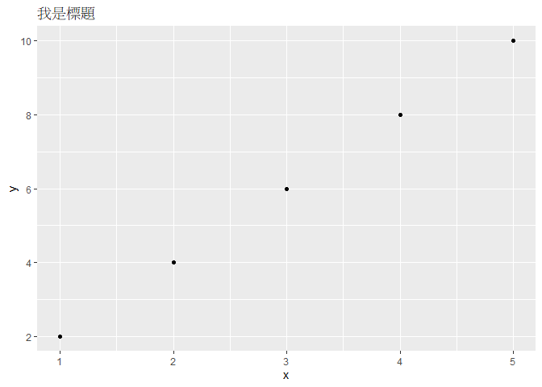

```r
p <- ggplot(df, aes(x, y))+geom_point()
p+ggtitle("我是標題")
```

```r
library(readr)
B <- read_csv("C:/Users/user/Desktop/PyTest_VScode/PythonTEST/20220914_(2版)省委書記講話_202101_202208(三分級).csv")
```

```
## ──────────────────────────────────────────────────────── Delimiter: "," chr
## (4): title, Name, Province, content dbl (6): ...1, ...2, ...3, Lev1, Lev2, Lev3
```

```r
View(B)


library(lubridate)
library(scales)
```

```r
library(ggplot2)
library("reshape2")
library(dplyr)
library(forcats)
library(dplyr)
PPP <- c('尹力' ,'尹弘', '王君正' ,'王建軍' , '王寧', '王蒙徽', '王曉暉', '石泰峰' ,'吳政隆' ,'李干杰',   '李希' ,  '李強' ,'李鴻忠', '沈曉明', '易煉紅', '林武' ,'信長星', '倪岳峰' ,'孫紹騁' ,'袁家軍', '馬興瑞' ,'張國清', '張慶偉', '梁言順' ,  '許勤', '陳敏爾' ,'景俊海' ,'劉國中'  , '劉寧' ,'樓陽生' ,  '蔡奇' ,'鄭柵潔','諶貽琴' ,'王東峰', '陳潤兒', '彭清華', '應勇')
QQQ <- c('福建省' ,'甘肅省', '西藏自治區' ,'青海省' , '雲南省', '湖北省', '四川省', '內蒙古自治區' ,'江蘇省' ,'山東省',   '廣東省' ,  '上海市' ,'天津市', '海南省', '江西省', '山西省' ,'青海省', '河北省' ,'內蒙古自治區' ,'浙江省', '新疆維吾爾自治區' ,'遼寧省', '湖南省', '寧夏回族自治區' ,  '黑龍江省', '重慶市' ,'吉林省' ,'陝西省'  , '廣西壯族自治區' ,'河南省' ,  '北京市' ,'安徽省','貴州省' ,'河北省', '寧夏回族自治區', '四川省', '湖北省')


my_order <- as.character(c("2021-01", "2021-02", "2021-03", "2021-04", "2021-05", "2021-06", "2021-07", "2021-08","2021-09","2021-10","2021-11","2021-12","2022-01","2022-02","2022-03","2022-04","2022-05","2022-06","2022-07","2022-08"))



for(i in c(1:2)){

  D <- B%>%filter(Name == PPP[i])
  D$pubtime <- as.Date(D$pubtime ,formats = c("%Y-%m"))

  R1 <- interval(as.POSIXct("2021-01-01"), as.POSIXct("2021-01-31"))
  R2 <- interval(as.POSIXct("2021-02-01"), as.POSIXct("2021-02-28"))
  R3 <- interval(as.POSIXct("2021-03-01"), as.POSIXct("2021-03-31"))
  R4 <- interval(as.POSIXct("2021-04-01"), as.POSIXct("2021-04-30"))
  R5 <- interval(as.POSIXct("2021-05-01"), as.POSIXct("2021-05-31"))
  R6 <- interval(as.POSIXct("2021-06-01"), as.POSIXct("2021-06-30"))
  R7 <- interval(as.POSIXct("2021-07-01"), as.POSIXct("2021-07-31"))
  R8 <- interval(as.POSIXct("2021-08-01"), as.POSIXct("2021-08-31"))
  R9 <- interval(as.POSIXct("2021-09-01"), as.POSIXct("2021-09-30"))
  R10 <- interval(as.POSIXct("2021-10-01"), as.POSIXct("2021-10-31"))
  R11 <- interval(as.POSIXct("2021-11-01"), as.POSIXct("2021-11-30"))
  R12 <- interval(as.POSIXct("2021-12-01"), as.POSIXct("2021-12-31"))
  R13 <- interval(as.POSIXct("2022-01-01"), as.POSIXct("2022-01-31"))
  R14 <- interval(as.POSIXct("2022-02-01"), as.POSIXct("2022-02-28"))
  R15 <- interval(as.POSIXct("2022-03-01"), as.POSIXct("2022-03-31"))
  R16 <- interval(as.POSIXct("2022-04-01"), as.POSIXct("2022-04-30"))
  R17 <- interval(as.POSIXct("2022-05-01"), as.POSIXct("2022-05-31"))
  R18 <- interval(as.POSIXct("2022-06-01"), as.POSIXct("2022-06-30"))
  R19 <- interval(as.POSIXct("2022-07-01"), as.POSIXct("2022-07-31"))
  R20 <- interval(as.POSIXct("2022-08-01"), as.POSIXct("2022-08-31"))
  FR1 <- D[D$pubtime %within% R1,]
  FR2 <- D[D$pubtime %within% R2,]
  FR3 <- D[D$pubtime %within% R3,]
  FR4 <- D[D$pubtime %within% R4,]
  FR5 <- D[D$pubtime %within% R5,]
  FR6 <- D[D$pubtime %within% R6,]
  FR7 <- D[D$pubtime %within% R7,]
  FR8 <- D[D$pubtime %within% R8,]
  FR9 <- D[D$pubtime %within% R9,]
  FR10 <- D[D$pubtime %within% R10,]
  FR11 <- D[D$pubtime %within% R11,]
  FR12 <- D[D$pubtime %within% R12,]
  FR13 <- D[D$pubtime %within% R13,]
  FR14 <- D[D$pubtime %within% R14,]
  FR15 <- D[D$pubtime %within% R15,]
  FR16 <- D[D$pubtime %within% R16,]
  FR17 <- D[D$pubtime %within% R17,]
  FR18 <- D[D$pubtime %within% R18,]
  FR19 <- D[D$pubtime %within% R19,]
  FR20 <- D[D$pubtime %within% R20,]

    Data <-
    data.frame(
      t = c("2021-01", "2021-02", "2021-03", "2021-04", "2021-05", "2021-06", "2021-07", "2021-08","2021-09","2021-10","2021-11","2021-12","2022-01","2022-02","2022-03","2022-04","2022-05","2022-06","2022-07","2022-08"),
      L1 = c(
        sum(FR1$Lev1) / length(FR1$title),
        sum(FR2$Lev1) / length(FR2$title),
        sum(FR3$Lev1) / length(FR3$title),
        sum(FR4$Lev1) / length(FR4$title),
        sum(FR5$Lev1) / length(FR5$title),
        sum(FR6$Lev1) / length(FR6$title),
        sum(FR7$Lev1) / length(FR7$title),
        sum(FR8$Lev1) / length(FR8$title),
        sum(FR9$Lev1) / length(FR9$title),
        sum(FR10$Lev1) / length(FR10$title),
        sum(FR11$Lev1) / length(FR11$title),
        sum(FR12$Lev1) / length(FR12$title),
        sum(FR13$Lev1) / length(FR13$title),
        sum(FR14$Lev1) / length(FR14$title),
        sum(FR15$Lev1) / length(FR15$title),
        sum(FR16$Lev1) / length(FR16$title),
        sum(FR17$Lev1) / length(FR17$title),
        sum(FR18$Lev1) / length(FR18$title),
        sum(FR19$Lev1) / length(FR19$title),
        sum(FR20$Lev1) / length(FR20$title)
      ),
      L2 = c(
        sum(FR1$Lev2) / length(FR1$title),
        sum(FR2$Lev2) / length(FR2$title),
        sum(FR3$Lev2) / length(FR3$title),
        sum(FR4$Lev2) / length(FR4$title),
        sum(FR5$Lev2) / length(FR5$title),
        sum(FR6$Lev2) / length(FR6$title),
        sum(FR7$Lev2) / length(FR7$title),
        sum(FR8$Lev2) / length(FR8$title),
        sum(FR9$Lev2) / length(FR9$title),
        sum(FR10$Lev2) / length(FR10$title),
        sum(FR11$Lev2) / length(FR11$title),
        sum(FR12$Lev2) / length(FR12$title),
        sum(FR13$Lev2) / length(FR13$title),
        sum(FR14$Lev2) / length(FR14$title),
        sum(FR15$Lev2) / length(FR15$title),
        sum(FR16$Lev2) / length(FR16$title),
        sum(FR17$Lev2) / length(FR17$title),
        sum(FR18$Lev2) / length(FR18$title),
        sum(FR19$Lev2) / length(FR19$title),
        sum(FR20$Lev2) / length(FR20$title)
      ),
      L3 = c(
        sum(FR1$Lev3) / length(FR1$title),
        sum(FR2$Lev3) / length(FR2$title),
        sum(FR3$Lev3) / length(FR3$title),
        sum(FR4$Lev3) / length(FR4$title),
        sum(FR5$Lev3) / length(FR5$title),
        sum(FR6$Lev3) / length(FR6$title),
        sum(FR7$Lev3) / length(FR7$title),
        sum(FR8$Lev3) / length(FR8$title),
        sum(FR9$Lev3) / length(FR9$title),
        sum(FR10$Lev3) / length(FR10$title),
        sum(FR11$Lev3) / length(FR11$title),
        sum(FR12$Lev3) / length(FR12$title),
        sum(FR13$Lev3) / length(FR13$title),
        sum(FR14$Lev3) / length(FR14$title),
        sum(FR15$Lev3) / length(FR15$title),
        sum(FR16$Lev3) / length(FR16$title),
        sum(FR17$Lev3) / length(FR17$title),
        sum(FR18$Lev3) / length(FR18$title),
        sum(FR19$Lev3) / length(FR19$title),
        sum(FR20$Lev3) / length(FR20$title)
      )
    )

    View(Data)

    data_long <- melt(Data, id = "t")

  #View(data_long)

  #,PPP[i],
      P1 <- data_long %>% arrange(value)  %>%
        ggplot(mapping = aes(x = t,y = value, fill = forcats::fct_rev(variable))) + geom_area()  + xlab("時間") + theme_bw()  + geom_col()+
        ylab("提及比例") + labs(
          subtitle = paste0("【",QQQ[i],"委書記",PPP[i],"】對習近平領導地位表態三分類佔該月總發言篇數比例 \n 2021.01.01～2022.08.31")) + scale_y_continuous(limits = c(0, 2), labels = percent) +
        scale_x_discrete(
          limits = function(x)
            my_order[my_order %in% x]
        ) +
        scale_fill_discrete(
          labels = c(
            "最高級",   #:顶梁柱,主心骨,\n定盘星,指南针,明灯,\n灯塔,补钙铸魂",
            "比較級",  #:导师,领袖,\n统帅,舵手,伟人,掌舵,\n把舵,引航,统领,英明,卓越",
            "原級"  #:核心"
          ),#"原級:核心","比較級:导师,领袖,\n统帅,舵手,伟人,掌舵,\n把舵,引航,统领,英明,卓越","最高級:顶梁柱,主心骨,\n定盘星,指南针,明灯,\n灯塔,补钙铸魂,思想伟力"
          guide = guide_legend(
            title = "三分級",
            title.position = "top",
            label.position = "bottom",
            label.hjust = 0.5,
            label.vjust = 1,
            label.theme = element_text(angle = 0),
            reverse = TRUE
          )
        ) +
        theme(
          axis.text.x = element_text(
            color = "black",
            size = 10,
            angle = 45,
            hjust = .9,
            vjust = .75,
            face = "plain"
          ),
          axis.text.y = element_text(
            color = "black",
            size = 10,
            angle = 0,
            hjust = 1,
            vjust = 0,
            face = "plain"
          ),
          axis.title.x = element_text(
            color = "black",
            size = 10,
            angle = 0,
            hjust = .5,
            vjust = 0,
            face = "plain"
          ),
          axis.title.y = element_text(
            color = "black",
            size = 10,
            angle = 90,
            hjust = .5,
            vjust = .5,
            face = "plain"
          ),
          legend.text = element_text(size = 12, vjust = .5)
        )

    #P1
    ggsave(paste0(PPP[i],".png"), units = "cm", plot = P1, path ="C:/Users/user/Desktop")
}
```

```
## Saving 17.8 x 12.7 cm image
## Saving 17.8 x 12.7 cm image
```

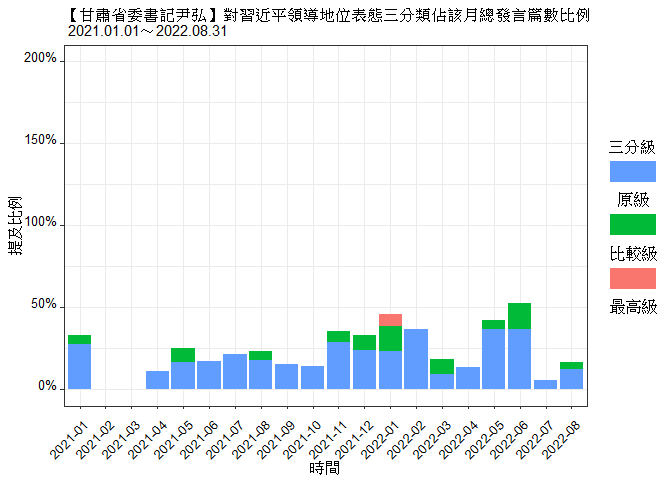

```r
P1
```

> gpt小僕人: > ggplot2 包含許多函數，可用於創建不同類型的圖表、應用各種美學特徵和修改視覺效果。以下是常用的 ggplot2 函數列表： > ggplot() - 創建 ggplot 物件的主要函數，它是一個空白畫布，可以在上面添加數據和圖層。 > aes() - 一個用於指定美學特徵的函數，如數據點的 x 和 y 座標、顏色、形狀和大小等。 > geom_point() - 一個用於添加點到圖表的函數。 > geom_line() - 一個用於添加線到圖表的函數。 > geom_bar() - 一個用於創建條形圖的函數。 > geom_histogram() - 一個用於創建直方圖的函數。 > geom_density() - 一個用於創建密度圖的函數。 > geom_boxplot() - 一個用於創建箱形圖的函數。 > geom_jitter() - 一個用於將抖動添加到數據點以減少重疊的函數。 > facet_wrap() 和 facet_grid() - 用於創建多面板圖，其中數據根據一個或多個分類變量分成子集。 > labs() - 用於自定義圖表標題、軸標籤和圖例的函數。 > scale_x_continuous() 和 scale_y_continuous() - 用於自定義 x 和 y 軸的範圍和標籤的函數。 > theme() - 用於修改整個圖表的外觀和感覺，例如字體大小、背景顏色和網格線等。 > 這當然並不是所有 ggplot2 函數的詳盡列表，但它涵蓋了一些最常用的函數。

## 練習2

請載入「正部級資料練習用」，挑選出包含「习近平」三個字的新聞，然後印出每個月出現有關習近平新聞的次數圖。 下面已經處理好資料，只要畫圖即可。用折線圖、直方圖或任何圖呈現都可以，只是請務必加上圖表名稱、xy軸名稱。

```r
library(readr)
data <- read_csv("C:/Users/user/Desktop/2023_R與言教學/正部級資料練習用.csv")
```

```
## ──────────────────────────────────────────────────────── Delimiter: "," chr
## (5): Name, title, url, sitename, Content dbl (2): ...1, Unnamed: 0 dttm (1):
## pubtime
```

```r
View(data)

#把有習近平三個字的rows記錄下來
XiList <- grep("习近平",data$title,value = F)

data$Xi <- c(NA)
for(i in c(1:length(data$Content))){
  if(i %in% XiList ){
    data$Xi[i] = 1
  }else{
    data$Xi[i] = 0
  }
}



#處理資料的時間格式，讓資料變成按月計次
library(dplyr)
library(ggplot2)
data$pubtime <- as.Date(data$pubtime, format="%Y-%m")
Newdata <- data %>% group_by(month = lubridate::floor_date(pubtime, 'month')) %>%summarise(XJP = sum(Xi))
View(Newdata)
```

## 練習2解答

```r
library(xkcd)
```

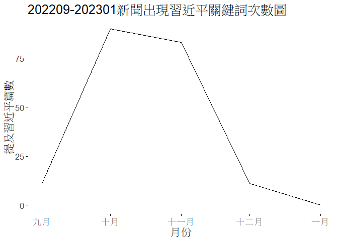

```r
p <- ggplot(Newdata, aes(x = month,  y = XJP))+ geom_line() +xlab("月份")+ylab("提及習近平篇數")+ggtitle("202209-202301新聞出現習近平關鍵詞次數圖")
p+theme_xkcd()
```

```r
#http://xkcd.r-forge.r-project.org/
#http://www.sthda.com/english/wiki/ggplot2-multiplot-put-multiple-graphs-on-the-same-page-using-ggplot2
```

## 回家作業

載入「正部級資料練習用」，挑選出包含「李克強」資料的講話。符合條件的給1，不符合條件的給0。然後印出每「週」出現有關李克強新聞的次數圖。 用折線圖、直方圖或任何圖呈現都可以，只是請務必加上圖表名稱、xy軸名稱。 > hint:研究一下怎麼按照每周來改變資料格式 > https://www.rdocumentation.org/packages/lubridate/versions/1.3.3/topics/floor_date